# 重賞レース予測レポート【毎時自動更新中】

作成日時: 2025/09/07 10:07:32

☞ [マニュアル(pdf)](https://ryutoro-galois.github.io/keiba-predictor/manual/manual.pdf)

☞ 過去5年の同一レース結果: [2024年](https://ryutoro-galois.github.io/keiba-predictor/report/PredResult_2024y_raceDate_20240907_20240908.html), [2023年](https://ryutoro-galois.github.io/keiba-predictor/report/PredResult_2023y_raceDate_20230909_20230910.html), [2022年](https://ryutoro-galois.github.io/keiba-predictor/report/PredResult_2022y_raceDate_20220910_20220911.html), [2021年](https://ryutoro-galois.github.io/keiba-predictor/report/PredResult_2021y_raceDate_20210911_20210912.html), [2020年](https://ryutoro-galois.github.io/keiba-predictor/report/PredResult_2020y_raceDate_20200912_20200913.html)

☞ 過去4週間の別レース結果: [1週前(8/31)](https://ryutoro-galois.github.io/keiba-predictor/report/PredResult_2025y_raceDate_20250831_20250831.html), [2週前(8/24)](https://ryutoro-galois.github.io/keiba-predictor/report/PredResult_2025y_raceDate_20250824_20250824.html), [3週前(8/16-17)](https://ryutoro-galois.github.io/keiba-predictor/report/PredResult_2025y_raceDate_20250816_20250817.html), [4週前(8/9-10)](https://ryutoro-galois.github.io/keiba-predictor/report/PredResult_2025y_raceDate_20250809_20250810.html)

☞ netkeiba: [京成杯オータムハンデ(GⅢ)](https://race.netkeiba.com/race/shutuba.html?race_id=202506040111&rf=race_list), [札幌2歳ステークス(GⅢ)](https://race.netkeiba.com/race/shutuba.html?race_id=202501020511&rf=race_list), [紫苑ステークス(GⅡ)](https://race.netkeiba.com/race/shutuba.html?race_id=202506040211&rf=race_list), [セントウルステークス(GⅡ)](https://race.netkeiba.com/race/shutuba.html?race_id=202509040211&rf=race_list)

## 0. 推し馬予測 (AI予測)

### 【京成杯オータムハンデ(GⅢ) 2025/09/06(土)】

- 本命(◎): 1-3着内確率(勝負強さ)が1位の馬
- 対抗(◯): 1-3着内確率が2-N位(20%程度以上)の中で予測タイムが最も速い馬
- 3番手(▲): 1-3着内確率が2-N位(20%程度以上)のでダークホース確率が最も高い馬
- 穴: ダークホース確率が上位1-M位(40%程度以上)の中で1-3着内確率が最も高い馬

| 推し馬 | 枠番 | 馬番 | 人気 | オッズ | 馬名 | 騎手 | 調教師 | 予測タイム(sec) | 1_順位 | 1-3着内確率(%) | 2_順位 | ﾀﾞｰｸﾎｰｽ確率(%) | 3_順位 |
| --- | --- | --- | --- | --- | --- | --- | --- | --- | --- | --- | --- | --- | --- |
| 本命(◎) | 5 | 10 | 6 | 12.5 | カラマティアノス | 石川裕紀人 | 奥村武 | 94.4 | 3 | 26.7 | 1 | 1.4 | 12 |
| 対抗(◯) | 6 | 11 | 1 | 2.8 | エリカエクスプレス | 戸崎圭太 | 杉山晴紀 | 90.3 | 1 | 22.4 | 3 | 0.4 | 16 |
| 3番手(▲) | 4 | 8 | 5 | 11.2 | シヴァース | 内田博幸 | 友道康夫 | 93.9 | 2 | 20.8 | 4 | 1.5 | 10 |
| 穴 | 1 | 1 | 13 | 89.5 | ホウオウラスカーズ | 木幡巧也 | 高木登 | 97.7 | 15 | 6.9 | 14 | 43.1 | 1 |

### 【札幌2歳ステークス(GⅢ) 2025/09/06(土)】

- 本命(◎): 1-3着内確率(勝負強さ)が1位の馬
- 対抗(◯): 1-3着内確率が2-N位(20%程度以上)の中で予測タイムが最も速い馬
- 3番手(▲): 1-3着内確率が2-N位(20%程度以上)のでダークホース確率が最も高い馬
- 穴: ダークホース確率が上位1-M位(40%程度以上)の中で1-3着内確率が最も高い馬

| 推し馬 | 枠番 | 馬番 | 人気 | オッズ | 馬名 | 騎手 | 調教師 | 予測タイム(sec) | 1_順位 | 1-3着内確率(%) | 2_順位 | ﾀﾞｰｸﾎｰｽ確率(%) | 3_順位 |
| --- | --- | --- | --- | --- | --- | --- | --- | --- | --- | --- | --- | --- | --- |
| 本命(◎) | 7 | 10 | 2 | 4.2 | アーレムアレス | 菱田裕二 | 橋口慎介 | 118.0 | 10 | 56.4 | 1 | 0.5 | 9 |
| 対抗(◯) | 4 | 4 | 1 | 3.4 | ショウナンガルフ | 池添謙一 | 須貝尚介 | 108.5 | 1 | 23.6 | 5 | 0.5 | 11 |
| 3番手(▲) | 8 | 11 | 4 | 5.3 | スマートプリエール | 武豊 | 大久保龍志 | 117.1 | 2 | 39.5 | 3 | 0.5 | 8 |
| 穴 | 1 | 1 | 10 | 31.1 | ジーネキング | 斎藤新 | 斎藤誠 | 117.6 | 8 | 13.9 | 9 | 47.3 | 1 |

- 本命(◎): 1-3着内確率(勝負強さ)が1位の馬
- 対抗(◯): 1-3着内確率が2-N位(20%程度以上)の中で予測タイムが最も速い馬
- 3番手(▲): 1-3着内確率が2-N位(20%程度以上)のでダークホース確率が最も高い馬
- 穴: ダークホース確率が上位1-M位(40%程度以上)の中で1-3着内確率が最も高い馬

| 推し馬 | 枠番 | 馬番 | 人気 | オッズ | 馬名 | 騎手 | 調教師 | 予測タイム(sec) | 1_順位 | 1-3着内確率(%) | 2_順位 | ﾀﾞｰｸﾎｰｽ確率(%) | 3_順位 |
| --- | --- | --- | --- | --- | --- | --- | --- | --- | --- | --- | --- | --- | --- |
| 本命(◎) | 4 | 5 | 2 | 4.1 | ジョスラン | Ｃ．ルメール | 鹿戸雄一 | 126.8 | 13 | 28.2 | 1 | 0.8 | 13 |
| 対抗(◯) | 1 | 1 | 1 | 3.1 | リンクスティップ | 北村友一 | 西村真幸 | 118.0 | 1 | 26.2 | 2 | 0.9 | 12 |
| 3番手(▲) | 8 | 13 | 6 | 11.9 | テリオスララ | 鮫島克駿 | 田島俊明 | 126.6 | 9 | 23.0 | 4 | 2.2 | 7 |
| 穴 | 7 | 11 | 8 | 20.5 | サヴォンリンナ | 吉田隼人 | 田中克典 | 126.6 | 9 | 12.6 | 7 | 60.4 | 6 |

### 【セントウルステークス(GⅡ) 2025/09/07(日)】

- 本命(◎): 1-3着内確率(勝負強さ)が1位の馬
- 対抗(◯): 1-3着内確率が2-N位(20%程度以上)の中で予測タイムが最も速い馬
- 3番手(▲): 1-3着内確率が2-N位(20%程度以上)のでダークホース確率が最も高い馬
- 穴: ダークホース確率が上位1-M位(40%程度以上)の中で1-3着内確率が最も高い馬

| 推し馬 | 枠番 | 馬番 | 人気 | オッズ | 馬名 | 騎手 | 調教師 | 予測タイム(sec) | 1_順位 | 1-3着内確率(%) | 2_順位 | ﾀﾞｰｸﾎｰｽ確率(%) | 3_順位 |
| --- | --- | --- | --- | --- | --- | --- | --- | --- | --- | --- | --- | --- | --- |
| 本命(◎) | 2 | 3 | 2 | 3.8 | ママコチャ | 岩田望来 | 池江泰寿 | 74.0 | 12 | 41.9 | 1 | 0.7 | 15 |
| 対抗(◯) | 2 | 4 | 4 | 10.2 | エコロジーク | 田口貫太 | 森秀行 | 68.6 | 2 | 30.7 | 2 | 1.9 | 11 |
| 3番手(▲) | 3 | 6 | 6 | 16.3 | アブキールベイ | 吉村誠之助 | 坂口智康 | 69.8 | 3 | 23.9 | 3 | 1.8 | 12 |
| 穴 | 4 | 8 | 16 | 163.8 | レッドアヴァンティ | 富田暁 | 尾関知人 | 69.9 | 4 | 12.1 | 7 | 45.8 | 1 |

## 1. 予測チャート (タイム/勝負強さ)

### 【京成杯オータムハンデ(GⅢ)】

2025/09/06(土), 06_中山, 芝右外1600m

[interactive chart not shown]

### 【札幌2歳ステークス(GⅢ)】

2025/09/06(土), 01_札幌, 芝右1800m

[interactive chart not shown]

2025/09/07(日), 06_中山, 芝右2000m

[interactive chart not shown]

### 【セントウルステークス(GⅡ)】

2025/09/07(日), 09_阪神, 芝右1200m

[interactive chart not shown]

## 2. オッズモニタリング (毎時)

### 【京成杯オータムハンデ】

[interactive chart not shown]

### 【札幌2歳ステークス】

[interactive chart not shown]

### 【紫苑ステークス】

[interactive chart not shown]

### 【セントウルステークス】

[interactive chart not shown]

## 3. 出馬表

### 【京成杯オータムハンデ 2025/09/06(土) 】

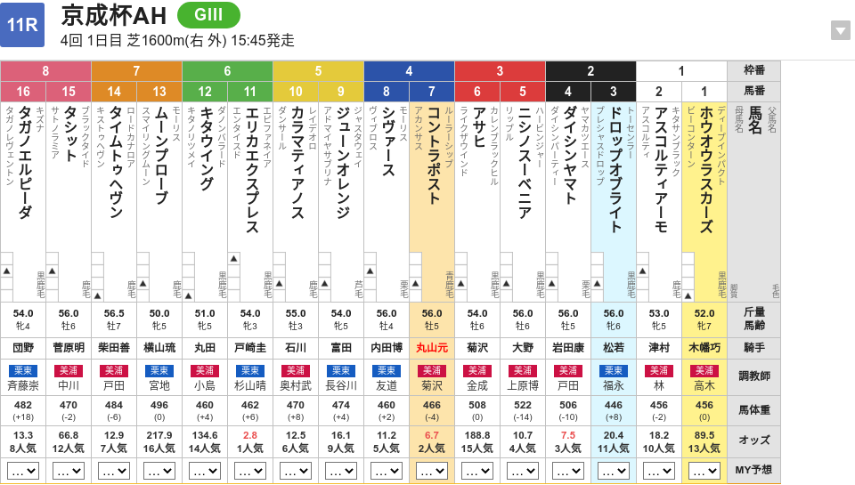

### 【札幌2歳ステークス 2025/09/06(土) 】

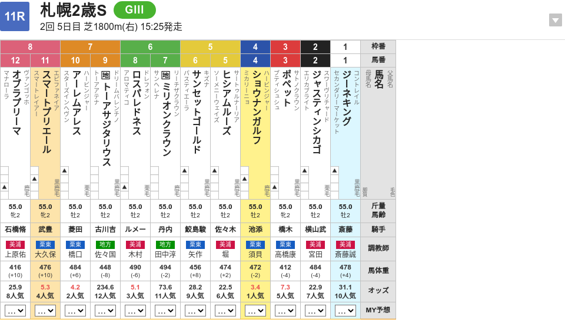

### 【紫苑ステークス 2025/09/07(日) 】

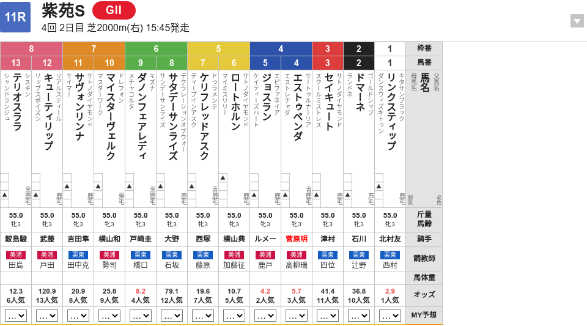

### 【セントウルステークス 2025/09/07(日) 】

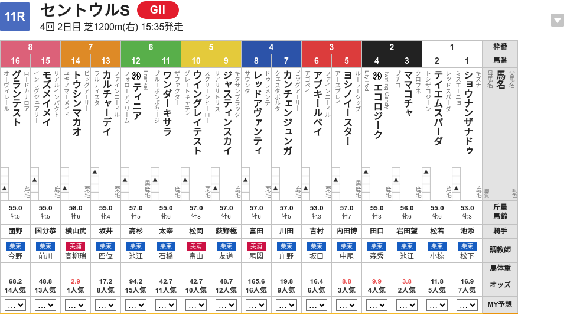

## 4. 単勝予測結果

### 【京成杯オータムハンデ(GⅢ) 2025/09/06(土)】

| 枠番 | 馬番 | 人気 | オッズ | 馬名 | 騎手 | 調教師 | 予測タイム(sec) | 1_順位 | 1-3着内確率(%) | 2_順位 | ﾀﾞｰｸﾎｰｽ確率(%) | 3_順位 |
| --- | --- | --- | --- | --- | --- | --- | --- | --- | --- | --- | --- | --- |
| 1 | 1 | 13 | 89.5 | ホウオウラスカーズ | 木幡巧也 | 高木登 | 97.7 | 15 | 6.9 | 14 | 43.1 | 1 |
| 1 | 2 | 10 | 18.2 | アスコルティアーモ | 津村明秀 | 林徹 | 96.3 | 6 | 13.5 | 7 | 36.0 | 2 |
| 2 | 3 | 11 | 20.4 | ドロップオブライト | 松若風馬 | 福永祐一 | 96.3 | 7 | 6.8 | 15 | 14.0 | 6 |
| 2 | 4 | 3 | 7.5 | ダイシンヤマト | 岩田康誠 | 戸田博文 | 97.6 | 14 | 18.4 | 5 | 0.8 | 14 |
| 3 | 5 | 4 | 10.7 | ニシノスーベニア | 大野拓弥 | 上原博之 | 97.5 | 13 | 9.3 | 10 | 1.8 | 9 |
| 3 | 6 | 15 | 188.8 | アサヒ | 菊沢一樹 | 金成貴史 | 98.3 | 16 | 10.3 | 9 | 27.3 | 4 |
| 4 | 7 | 2 | 6.7 | コントラポスト | 丸山元気 | 菊沢隆徳 | 97.2 | 11 | 17.8 | 6 | 0.4 | 15 |
| 4 | 8 | 5 | 11.2 | シヴァース | 内田博幸 | 友道康夫 | 93.9 | 2 | 20.8 | 4 | 1.5 | 10 |
| 5 | 9 | 9 | 16.1 | ジューンオレンジ | 富田暁 | 長谷川浩大 | 97.3 | 12 | 7.1 | 13 | 21.4 | 5 |
| 5 | 10 | 6 | 12.5 | カラマティアノス | 石川裕紀人 | 奥村武 | 94.4 | 3 | 26.7 | 1 | 1.4 | 12 |

[output cut: 6 more lines]

### 【札幌2歳ステークス(GⅢ) 2025/09/06(土)】

| 枠番 | 馬番 | 人気 | オッズ | 馬名 | 騎手 | 調教師 | 予測タイム(sec) | 1_順位 | 1-3着内確率(%) | 2_順位 | ﾀﾞｰｸﾎｰｽ確率(%) | 3_順位 |
| --- | --- | --- | --- | --- | --- | --- | --- | --- | --- | --- | --- | --- |
| 1 | 1 | 10 | 31.1 | ジーネキング | 斎藤新 | 斎藤誠 | 117.6 | 8 | 13.9 | 9 | 47.3 | 1 |
| 2 | 2 | 7 | 22.9 | ジャスティンシカゴ | 横山武史 | 宮田敬介 | 118.0 | 11 | 16.4 | 6 | 37.8 | 2 |
| 3 | 3 | 5 | 7.3 | ポペット | 橋木太希 | 高橋康之 | 117.3 | 4 | 33.3 | 4 | 0.5 | 10 |
| 4 | 4 | 1 | 3.4 | ショウナンガルフ | 池添謙一 | 須貝尚介 | 108.5 | 1 | 23.6 | 5 | 0.5 | 11 |
| 5 | 5 | 6 | 22.5 | ヒシアムルーズ | 佐々木大輔 | 堀宣行 | 118.0 | 12 | 14.3 | 8 | 1.2 | 7 |
| 5 | 6 | 9 | 28.2 | サンセットゴールド | 鮫島克駿 | 矢作芳人 | 117.6 | 9 | 13.7 | 10 | 33.9 | 5 |
| 6 | 7 | 11 | 73.6 | ミリオンクラウン | 丹内祐次 | 田中淳司 | 117.5 | 7 | 8.0 | 11 | 36.6 | 3 |
| 6 | 8 | 3 | 5.1 | ロスパレドネス | Ｃ．ルメール | 木村哲也 | 117.3 | 3 | 44.3 | 2 | 0.5 | 12 |
| 7 | 9 | 12 | 234.6 | トーアサジタリウス | 古川吉洋 | 佐々木国明 | 117.5 | 6 | 7.8 | 12 | 35.1 | 4 |
| 7 | 10 | 2 | 4.2 | アーレムアレス | 菱田裕二 | 橋口慎介 | 118.0 | 10 | 56.4 | 1 | 0.5 | 9 |

[output cut: 2 more lines]

| 枠番 | 馬番 | 人気 | オッズ | 馬名 | 騎手 | 調教師 | 予測タイム(sec) | 1_順位 | 1-3着内確率(%) | 2_順位 | ﾀﾞｰｸﾎｰｽ確率(%) | 3_順位 |
| --- | --- | --- | --- | --- | --- | --- | --- | --- | --- | --- | --- | --- |
| 1 | 1 | 1 | 3.1 | リンクスティップ | 北村友一 | 西村真幸 | 118.0 | 1.0 | 26.2 | 2 | 0.9 | 12 |
| 2 | 2 | 10 | 34.8 | ドマーネ | 石川裕紀人 | 辻野泰之 | 126.3 | 4.5 | 10.6 | 10 | 61.7 | 4 |
| 3 | 3 | 11 | 40.9 | セイキュート | 津村明秀 | 四位洋文 | 126.3 | 4.5 | 10.7 | 9 | 73.5 | 1 |
| 4 | 4 | 3 | 5.9 | エストゥペンダ | 菅原明良 | 高柳瑞樹 | 126.6 | 9.0 | 25.9 | 3 | 0.9 | 11 |
| 4 | 5 | 2 | 4.1 | ジョスラン | Ｃ．ルメール | 鹿戸雄一 | 126.8 | 13.0 | 28.2 | 1 | 0.8 | 13 |
| 5 | 6 | 5 | 10.3 | ロートホルン | 横山典弘 | 加藤征弘 | 126.6 | 9.0 | 22.2 | 5 | 2.1 | 8 |
| 5 | 7 | 7 | 18.9 | ケリフレッドアスク | 西塚洸二 | 藤原英昭 | 126.6 | 9.0 | 11.4 | 8 | 2.1 | 9 |
| 6 | 8 | 12 | 78.6 | サタデーサンライズ | 大野拓弥 | 石坂公一 | 126.0 | 2.5 | 9.2 | 12 | 68.3 | 3 |
| 6 | 9 | 4 | 7.8 | ダノンフェアレディ | 戸崎圭太 | 橋口慎介 | 126.6 | 9.0 | 20.9 | 6 | 1.5 | 10 |
| 7 | 10 | 9 | 24.8 | マイスターヴェルク | 横山和生 | 勢司和浩 | 126.6 | 9.0 | 9.1 | 13 | 61.1 | 5 |

[output cut: 3 more lines]

### 【セントウルステークス(GⅡ) 2025/09/07(日)】

| 枠番 | 馬番 | 人気 | オッズ | 馬名 | 騎手 | 調教師 | 予測タイム(sec) | 1_順位 | 1-3着内確率(%) | 2_順位 | ﾀﾞｰｸﾎｰｽ確率(%) | 3_順位 |
| --- | --- | --- | --- | --- | --- | --- | --- | --- | --- | --- | --- | --- |
| 1 | 1 | 7 | 16.6 | ショウナンザナドゥ | 池添謙一 | 松下武士 | 71.0 | 7 | 21.4 | 4 | 1.6 | 13 |
| 1 | 2 | 5 | 11.7 | テイエムスパーダ | 松若風馬 | 小椋研介 | 74.1 | 13 | 13.2 | 6 | 1.4 | 14 |
| 2 | 3 | 2 | 3.8 | ママコチャ | 岩田望来 | 池江泰寿 | 74.0 | 12 | 41.9 | 1 | 0.7 | 15 |
| 2 | 4 | 4 | 10.2 | エコロジーク | 田口貫太 | 森秀行 | 68.6 | 2 | 30.7 | 2 | 1.9 | 11 |
| 3 | 5 | 3 | 8.8 | ヨシノイースター | 内田博幸 | 中尾秀正 | 73.5 | 10 | 8.4 | 12 | 1.9 | 10 |
| 3 | 6 | 6 | 16.3 | アブキールベイ | 吉村誠之助 | 坂口智康 | 69.8 | 3 | 23.9 | 3 | 1.8 | 12 |
| 4 | 7 | 9 | 19.1 | カンチェンジュンガ | 川田将雅 | 庄野靖志 | 73.7 | 11 | 7.0 | 13 | 17.9 | 6 |
| 4 | 8 | 16 | 163.8 | レッドアヴァンティ | 富田暁 | 尾関知人 | 69.9 | 4 | 12.1 | 7 | 45.8 | 1 |
| 5 | 9 | 12 | 47.7 | ジャスティンスカイ | 荻野極 | 友道康夫 | 74.2 | 14 | 11.3 | 9 | 19.2 | 5 |
| 5 | 10 | 10 | 40.2 | ウイングレイテスト | 松岡正海 | 畠山吉宏 | 75.1 | 16 | 6.9 | 14 | 11.9 | 8 |

[output cut: 6 more lines]

## 5. 人気と着順の乖離率推移

### 【京成杯オータムハンデ_1998y_2019y】

[interactive chart not shown]

### 【札幌2歳ステークス_2001y_2019y】

[interactive chart not shown]

### 【紫苑ステークス_2016y_2019y】

[interactive chart not shown]

### 【セントウルステークス_1990y_2019y】

[interactive chart not shown]

### 【京成杯オータムハンデ_1998y_2019y】

| No | 開催年 | 不整合率(%) | 頭数 | 人気別着順(1-3位) | 人気別着順(全体) |
| --- | --- | --- | --- | --- | --- |
| 22 | 2019 | 67.3 | 16頭 | 4-5-10 | 4\|5\|10\|15\|3\|8\|2\|6\|12\|14\|1\|13\|7\|9\|16\|11 |
| 21 | 2018 | 22.8 | 15頭 | 1-3-2 | 1\|3\|2\|5\|8\|14\|10\|7\|4\|11\|12\|15\|13\|6\|9 |
| 20 | 2017 | 20.8 | 15頭 | 1-11-6 | 1\|11\|6\|2\|9\|7\|13\|15\|8\|14\|3\|4\|10\|5\|12 |
| 19 | 2016 | 22.4 | 15頭 | 1-6-2 | 1\|6\|2\|4\|9\|10\|11\|5\|12\|3\|8\|14\|7\|13\|15 |
| 18 | 2015 | 47.3 | 16頭 | 13-11-7 | 13\|11\|7\|3\|14\|10\|1\|2\|8\|5\|16\|12\|15\|9\|6\|4 |
| 17 | 2014 | 38.7 | 15頭 | 2-8-9 | 2\|8\|9\|5\|1\|10\|14\|6\|15\|11\|7\|13\|12\|3\|4 |
| 16 | 2013 | 59.4 | 14頭 | 3-2-7 | 3\|2\|7\|10\|9\|11\|6\|5\|13\|1\|8\|4\|14\|12 |
| 15 | 2012 | 45.9 | 16頭 | 2-6-4 | 2\|6\|4\|3\|12\|8\|1\|11\|15\|5\|16\|10\|7\|9\|13\|14 |
| 14 | 2011 | 39.9 | 14頭 | 2-7-3 | 2\|7\|3\|5\|1\|10\|11\|4\|12\|13\|8\|14\|6\|9 |
| 13 | 2010 | 59.8 | 14頭 | 4-7-5 | 4\|7\|5\|2\|3\|10\|9\|8\|1\|6\|13\|11\|14\|12 |

[output cut: 12 more lines]

### 【札幌2歳ステークス_2001y_2019y】

| No | 開催年 | 不整合率(%) | 頭数 | 人気別着順(1-3位) | 人気別着順(全体) |
| --- | --- | --- | --- | --- | --- |
| 19 | 2019 | 60.5 | 12頭 | 5-3-2 | 5\|3\|2\|4\|7\|1\|9\|6\|12\|10\|8\|11 |
| 18 | 2018 | 43.1 | 14頭 | 6-4-1 | 6\|4\|1\|8\|3\|11\|2\|5\|10\|9\|7\|12\|13\|14 |
| 17 | 2017 | 27.5 | 14頭 | 1-4-7 | 1\|4\|7\|5\|8\|2\|6\|10\|11\|3\|12\|13\|9\|14 |
| 16 | 2016 | 55.4 | 13頭 | 5-10-7 | 5\|10\|7\|9\|11\|12\|3\|1\|8\|2\|6\|4\|13 |
| 15 | 2015 | 27.9 | 14頭 | 2-1-8 | 2\|1\|8\|5\|3\|7\|10\|11\|12\|9\|4\|6\|14\|13 |
| 14 | 2014 | 42.6 | 14頭 | 5-11-7 | 5\|11\|7\|8\|2\|10\|1\|6\|12\|3\|4\|13\|14\|9 |
| 13 | 2013 | 36.9 | 14頭 | 2-4-6 | 2\|4\|6\|7\|1\|8\|11\|10\|3\|14\|13\|12\|9\|5 |
| 12 | 2012 | 38.4 | 14頭 | 3-1-9 | 3\|1\|9\|8\|7\|10\|2\|11\|4\|5\|12\|6\|13\|14 |
| 11 | 2011 | 12.0 | 13頭 | 1-2-5 | 1\|2\|5\|3\|7\|9\|4\|8\|12\|10\|11\|6\|13 |
| 10 | 2010 | 42.1 | 14頭 | 3-2-1 | 3\|2\|1\|4\|6\|10\|11\|13\|7\|5\|9\|12\|14\|8 |

[output cut: 9 more lines]

### 【紫苑ステークス_2016y_2019y】

| No | 開催年 | 不整合率(%) | 頭数 | 人気別着順(1-3位) | 人気別着順(全体) |
| --- | --- | --- | --- | --- | --- |
| 4 | 2019 | 26.9 | 15頭 | 2-6-1 | 2\|6\|1\|3\|8\|10\|7\|9\|13\|4\|5\|11\|14\|12\|15 |
| 3 | 2018 | 35.2 | 16頭 | 2-1-7 | 2\|1\|7\|6\|10\|11\|4\|13\|12\|9\|8\|14\|3\|5\|16\|15 |
| 2 | 2017 | 27.7 | 18頭 | 1-6-4 | 1\|6\|4\|13\|5\|2\|9\|7\|3\|10\|12\|8\|11\|17\|18\|14\|15\|16 |
| 1 | 2016 | 29.1 | 18頭 | 1-3-5 | 1\|3\|5\|7\|2\|13\|9\|12\|16\|10\|14\|6\|8\|15\|11\|4\|17\|18 |

### 【セントウルステークス_1990y_2019y】

| No | 開催年 | 不整合率(%) | 頭数 | 人気別着順(1-3位) | 人気別着順(全体) |
| --- | --- | --- | --- | --- | --- |
| 30 | 2019 | 33.1 | 13頭 | 1-7-3 | 1\|7\|3\|8\|12\|4\|5\|2\|11\|10\|9\|13\|6 |
| 29 | 2018 | 16.0 | 15頭 | 1-2-7 | 1\|2\|7\|11\|9\|3\|13\|10\|12\|5\|4\|6\|8\|15\|14 |
| 28 | 2017 | 38.3 | 14頭 | 1-6-4 | 1\|6\|4\|3\|8\|5\|11\|7\|2\|10\|14\|12\|9\|13 |
| 27 | 2016 | 17.3 | 13頭 | 1-2-9 | 1\|2\|9\|11\|6\|7\|3\|5\|4\|8\|10\|12\|13 |
| 26 | 2015 | 32.2 | 16頭 | 10-1-5 | 10\|1\|5\|3\|6\|16\|7\|2\|4\|15\|11\|14\|12\|9\|13\|8 |
| 25 | 2014 | 28.2 | 15頭 | 4-1-2 | 4\|1\|2\|11\|5\|8\|7\|3\|12\|14\|15\|10\|13\|9\|6 |
| 24 | 2013 | 24.1 | 13頭 | 2-1-3 | 2\|1\|3\|8\|11\|6\|7\|4\|9\|13\|10\|5\|12 |
| 23 | 2012 | 35.2 | 16頭 | 6-1-12 | 6\|1\|12\|3\|13\|4\|5\|8\|14\|10\|2\|11\|15\|7\|9\|16 |
| 22 | 2011 | 30.3 | 15頭 | 2-5-1 | 2\|5\|1\|4\|7\|3\|13\|12\|6\|8\|10\|11\|14\|9\|15 |
| 21 | 2010 | 49.2 | 15頭 | 4-2-5 | 4\|2\|5\|3\|10\|1\|11\|7\|6\|9\|8\|12\|14\|13\|15 |

[output cut: 20 more lines]

## 6. 1-3番人気馬の着順分類予測

### 【京成杯オータムハンデ】

| 分類 | 凡例 | 発生確率(%) | 当該レース | 当該レースランク | 直近1年間 |
| --- | --- | --- | --- | --- | --- |
| 8: 1,2,3番人気すべて着外 (8_darkhorse) | * \| * \| * | 18.2 | 0.55 | 0.99 | 0.73 |
| 1: 1番人気のみ (1_pop1) | 1 \| * \| * | 16.9 | 1.52 | 1.07 | 0.00 |
| 4: 1,2番人気のみ (4_pop12) | 1 \| 2 \| * | 16.4 | 1.48 | 0.66 | 0.33 |
| 5: 1,3番人気のみ (5_pop13) | 1 \| 3 \| * | 13.8 | 1.86 | 1.75 | 0.00 |
| 2: 2番人気のみ (2_pop2) | 2 \| * \| * | 9.9 | 0.89 | 1.08 | 0.00 |
| 6: 2,3番人気のみ (6_pop23) | 2 \| 3 \| * | 9.3 | 0.63 | 0.70 | 0.37 |
| 3: 3番人気のみ (3_pop3) | 3 \| * \| * | 8.5 | 2.30 | 2.18 | 0.00 |
| 7: 1,2,3番人気すべて着内 (7_pop123) | 1 \| 2 \| 3 | 7.0 | 0.95 | 1.06 | 0.00 |

### 【札幌2歳ステークス】

| 分類 | 凡例 | 発生確率(%) | 当該レース | 当該レースランク | 直近1年間 |
| --- | --- | --- | --- | --- | --- |
| 4: 1,2番人気のみ (4_pop12) | 1 \| 2 \| * | 16.6 | 1.33 | 0.66 | 0.33 |
| 1: 1番人気のみ (1_pop1) | 1 \| * \| * | 16.2 | 0.78 | 1.03 | 0.00 |
| 8: 1,2,3番人気すべて着外 (8_darkhorse) | * \| * \| * | 15.0 | 1.20 | 0.82 | 0.60 |
| 5: 1,3番人気のみ (5_pop13) | 1 \| 3 \| * | 13.9 | 1.67 | 1.76 | 0.00 |
| 6: 2,3番人気のみ (6_pop23) | 2 \| 3 \| * | 12.3 | 0.49 | 0.93 | 0.49 |
| 2: 2番人気のみ (2_pop2) | 2 \| * \| * | 10.0 | 1.20 | 1.09 | 0.00 |
| 3: 3番人気のみ (3_pop3) | 3 \| * \| * | 8.9 | 2.12 | 2.28 | 0.00 |
| 7: 1,2,3番人気すべて着内 (7_pop123) | 1 \| 2 \| 3 | 7.0 | 0.84 | 1.06 | 0.00 |

### 【紫苑ステークス】

| 分類 | 凡例 | 発生確率(%) | 当該レース | 当該レースランク | 直近1年間 |
| --- | --- | --- | --- | --- | --- |
| 8: 1,2,3番人気すべて着外 (8_darkhorse) | * \| * \| * | 18.2 | 0.00 | 2.27 | 0.00 |
| 1: 1番人気のみ (1_pop1) | 1 \| * \| * | 16.9 | 1.52 | 1.06 | 0.00 |
| 4: 1,2番人気のみ (4_pop12) | 1 \| 2 \| * | 16.4 | 0.21 | 0.32 | 0.16 |
| 5: 1,3番人気のみ (5_pop13) | 1 \| 3 \| * | 13.8 | 1.24 | 1.73 | 0.00 |
| 2: 2番人気のみ (2_pop2) | 2 \| * \| * | 9.9 | 0.00 | 1.24 | 0.00 |
| 6: 2,3番人気のみ (6_pop23) | 2 \| 3 \| * | 9.3 | 0.00 | 0.00 | 0.00 |
| 3: 3番人気のみ (3_pop3) | 3 \| * \| * | 8.5 | 0.00 | 2.12 | 0.00 |
| 7: 1,2,3番人気すべて着内 (7_pop123) | 1 \| 2 \| 3 | 7.0 | 0.00 | 1.75 | 0.00 |

### 【セントウルステークス】

| 分類 | 凡例 | 発生確率(%) | 当該レース | 当該レースランク | 直近1年間 |
| --- | --- | --- | --- | --- | --- |
| 4: 1,2番人気のみ (4_pop12) | 1 \| 2 \| * | 16.6 | 0.36 | 0.32 | 0.17 |
| 1: 1番人気のみ (1_pop1) | 1 \| * \| * | 16.2 | 0.71 | 0.62 | 0.00 |
| 8: 1,2,3番人気すべて着外 (8_darkhorse) | * \| * \| * | 15.0 | 2.63 | 0.00 | 0.00 |
| 5: 1,3番人気のみ (5_pop13) | 1 \| 3 \| * | 13.9 | 2.44 | 2.62 | 0.00 |
| 6: 2,3番人気のみ (6_pop23) | 2 \| 3 \| * | 12.3 | 0.00 | 0.00 | 0.00 |
| 2: 2番人気のみ (2_pop2) | 2 \| * \| * | 10.0 | 1.16 | 1.89 | 0.00 |
| 3: 3番人気のみ (3_pop3) | 3 \| * \| * | 8.9 | 1.56 | 1.68 | 0.00 |
| 7: 1,2,3番人気すべて着内 (7_pop123) | 1 \| 2 \| 3 | 7.0 | 1.23 | 1.32 | 0.00 |

## 7. 3連複予測結果

### 【京成杯オータムハンデ(GⅢ) 2025/09/06(土)】

| 分類 | 馬番 | 枠番 | 人気 | 平均予測タイム(sec) | 1-3着内確率(%) | ﾀﾞｰｸﾎｰｽ確率(%) | 馬名 | 騎手 | 調教師 |
| --- | --- | --- | --- | --- | --- | --- | --- | --- | --- |
| 1: 1番人気のみ (1_pop1) | 11-10-16 | 6-5-8 | 1-6-8 | 93.60 | 1.51 | 0.00 | エリカエクスプレス \| カラマティアノス \| タガノエルピーダ | 戸崎圭太 \| 石川裕紀人 \| 団野大成 | 杉山晴紀 \| 奥村武 \| 斉藤崇史 |
| 8: 1,2,3番人気すべて着外 (8_darkhorse) | 8-10-16 | 4-5-8 | 5-6-8 | 94.80 | 1.40 | 0.00 | シヴァース \| カラマティアノス \| タガノエルピーダ | 内田博幸 \| 石川裕紀人 \| 団野大成 | 友道康夫 \| 奥村武 \| 斉藤崇史 |
| 1: 1番人気のみ (1_pop1) | 11-8-10 | 6-4-5 | 1-5-6 | 92.87 | 1.24 | 0.00 | エリカエクスプレス \| シヴァース \| カラマティアノス | 戸崎圭太 \| 内田博幸 \| 石川裕紀人 | 杉山晴紀 \| 友道康夫 \| 奥村武 |
| 3: 3番人気のみ (3_pop3) | 4-10-16 | 2-5-8 | 3-6-8 | 96.03 | 1.24 | 0.00 | ダイシンヤマト \| カラマティアノス \| タガノエルピーダ | 岩田康誠 \| 石川裕紀人 \| 団野大成 | 戸田博文 \| 奥村武 \| 斉藤崇史 |
| 2: 2番人気のみ (2_pop2) | 7-10-16 | 4-5-8 | 2-6-8 | 95.90 | 1.20 | 0.00 | コントラポスト \| カラマティアノス \| タガノエルピーダ | 丸山元気 \| 石川裕紀人 \| 団野大成 | 菊沢隆徳 \| 奥村武 \| 斉藤崇史 |
| 1: 1番人気のみ (1_pop1) | 11-8-16 | 6-4-8 | 1-5-8 | 93.43 | 1.18 | 0.00 | エリカエクスプレス \| シヴァース \| タガノエルピーダ | 戸崎圭太 \| 内田博幸 \| 団野大成 | 杉山晴紀 \| 友道康夫 \| 斉藤崇史 |
| 5: 1,3番人気のみ (5_pop13) | 11-4-10 | 6-2-5 | 1-3-6 | 94.10 | 1.10 | 0.00 | エリカエクスプレス \| ダイシンヤマト \| カラマティアノス | 戸崎圭太 \| 岩田康誠 \| 石川裕紀人 | 杉山晴紀 \| 戸田博文 \| 奥村武 |
| 4: 1,2番人気のみ (4_pop12) | 11-7-10 | 6-4-5 | 1-2-6 | 93.97 | 1.06 | 0.00 | エリカエクスプレス \| コントラポスト \| カラマティアノス | 戸崎圭太 \| 丸山元気 \| 石川裕紀人 | 杉山晴紀 \| 菊沢隆徳 \| 奥村武 |
| 5: 1,3番人気のみ (5_pop13) | 11-4-16 | 6-2-8 | 1-3-8 | 94.67 | 1.04 | 0.00 | エリカエクスプレス \| ダイシンヤマト \| タガノエルピーダ | 戸崎圭太 \| 岩田康誠 \| 団野大成 | 杉山晴紀 \| 戸田博文 \| 斉藤崇史 |
| 3: 3番人気のみ (3_pop3) | 4-8-10 | 2-4-5 | 3-5-6 | 95.30 | 1.02 | 0.00 | ダイシンヤマト \| シヴァース \| カラマティアノス | 岩田康誠 \| 内田博幸 \| 石川裕紀人 | 戸田博文 \| 友道康夫 \| 奥村武 |

[output cut: 550 more lines]

### 【札幌2歳ステークス(GⅢ) 2025/09/06(土)】

| 分類 | 馬番 | 枠番 | 人気 | 平均予測タイム(sec) | 1-3着内確率(%) | ﾀﾞｰｸﾎｰｽ確率(%) | 馬名 | 騎手 | 調教師 |
| --- | --- | --- | --- | --- | --- | --- | --- | --- | --- |
| 6: 2,3番人気のみ (6_pop23) | 10-8-11 | 7-6-8 | 2-3-4 | 117.47 | 9.88 | 0.00 | アーレムアレス \| ロスパレドネス \| スマートプリエール | 菱田裕二 \| Ｃ．ルメール \| 武豊 | 橋口慎介 \| 木村哲也 \| 大久保龍志 |
| 6: 2,3番人気のみ (6_pop23) | 10-8-3 | 7-6-3 | 2-3-5 | 117.53 | 8.31 | 0.00 | アーレムアレス \| ロスパレドネス \| ポペット | 菱田裕二 \| Ｃ．ルメール \| 橋木太希 | 橋口慎介 \| 木村哲也 \| 高橋康之 |
| 2: 2番人気のみ (2_pop2) | 10-11-3 | 7-8-3 | 2-4-5 | 117.47 | 7.42 | 0.00 | アーレムアレス \| スマートプリエール \| ポペット | 菱田裕二 \| 武豊 \| 橋木太希 | 橋口慎介 \| 大久保龍志 \| 高橋康之 |
| 7: 1,2,3番人気すべて着内 (7_pop123) | 4-10-8 | 4-7-6 | 1-2-3 | 114.60 | 5.90 | 0.00 | ショウナンガルフ \| アーレムアレス \| ロスパレドネス | 池添謙一 \| 菱田裕二 \| Ｃ．ルメール | 須貝尚介 \| 橋口慎介 \| 木村哲也 |
| 3: 3番人気のみ (3_pop3) | 8-11-3 | 6-8-3 | 3-4-5 | 117.23 | 5.83 | 0.00 | ロスパレドネス \| スマートプリエール \| ポペット | Ｃ．ルメール \| 武豊 \| 橋木太希 | 木村哲也 \| 大久保龍志 \| 高橋康之 |
| 4: 1,2番人気のみ (4_pop12) | 4-10-11 | 4-7-8 | 1-2-4 | 114.53 | 5.27 | 0.00 | ショウナンガルフ \| アーレムアレス \| スマートプリエール | 池添謙一 \| 菱田裕二 \| 武豊 | 須貝尚介 \| 橋口慎介 \| 大久保龍志 |
| 4: 1,2番人気のみ (4_pop12) | 4-10-3 | 4-7-3 | 1-2-5 | 114.60 | 4.44 | 0.00 | ショウナンガルフ \| アーレムアレス \| ポペット | 池添謙一 \| 菱田裕二 \| 橋木太希 | 須貝尚介 \| 橋口慎介 \| 高橋康之 |
| 5: 1,3番人気のみ (5_pop13) | 4-8-11 | 4-6-8 | 1-3-4 | 114.30 | 4.14 | 0.00 | ショウナンガルフ \| ロスパレドネス \| スマートプリエール | 池添謙一 \| Ｃ．ルメール \| 武豊 | 須貝尚介 \| 木村哲也 \| 大久保龍志 |
| 6: 2,3番人気のみ (6_pop23) | 10-8-2 | 7-6-2 | 2-3-7 | 117.77 | 4.09 | 0.00 | アーレムアレス \| ロスパレドネス \| ジャスティンシカゴ | 菱田裕二 \| Ｃ．ルメール \| 横山武史 | 橋口慎介 \| 木村哲也 \| 宮田敬介 |
| 6: 2,3番人気のみ (6_pop23) | 10-8-12 | 7-6-8 | 2-3-8 | 117.60 | 3.73 | 0.00 | アーレムアレス \| ロスパレドネス \| オブラプリーマ | 菱田裕二 \| Ｃ．ルメール \| 石橋脩 | 橋口慎介 \| 木村哲也 \| 上原佑紀 |

[output cut: 210 more lines]

| 分類 | 馬番 | 枠番 | 人気 | 平均予測タイム(sec) | 1-3着内確率(%) | ﾀﾞｰｸﾎｰｽ確率(%) | 馬名 | 騎手 | 調教師 |
| --- | --- | --- | --- | --- | --- | --- | --- | --- | --- |
| 7: 1,2,3番人気すべて着内 (7_pop123) | 1-5-4 | 1-4-4 | 1-2-3 | 123.80 | 1.91 | 0.00 | リンクスティップ \| ジョスラン \| エストゥペンダ | 北村友一 \| Ｃ．ルメール \| 菅原明良 | 西村真幸 \| 鹿戸雄一 \| 高柳瑞樹 |
| 4: 1,2番人気のみ (4_pop12) | 1-5-13 | 1-4-8 | 1-2-6 | 123.80 | 1.70 | 0.00 | リンクスティップ \| ジョスラン \| テリオスララ | 北村友一 \| Ｃ．ルメール \| 鮫島克駿 | 西村真幸 \| 鹿戸雄一 \| 田島俊明 |
| 6: 2,3番人気のみ (6_pop23) | 5-4-13 | 4-4-8 | 2-3-6 | 126.67 | 1.68 | 0.00 | ジョスラン \| エストゥペンダ \| テリオスララ | Ｃ．ルメール \| 菅原明良 \| 鮫島克駿 | 鹿戸雄一 \| 高柳瑞樹 \| 田島俊明 |
| 4: 1,2番人気のみ (4_pop12) | 1-5-6 | 1-4-5 | 1-2-5 | 123.80 | 1.64 | 0.00 | リンクスティップ \| ジョスラン \| ロートホルン | 北村友一 \| Ｃ．ルメール \| 横山典弘 | 西村真幸 \| 鹿戸雄一 \| 加藤征弘 |
| 6: 2,3番人気のみ (6_pop23) | 5-4-6 | 4-4-5 | 2-3-5 | 126.67 | 1.62 | 0.00 | ジョスラン \| エストゥペンダ \| ロートホルン | Ｃ．ルメール \| 菅原明良 \| 横山典弘 | 鹿戸雄一 \| 高柳瑞樹 \| 加藤征弘 |
| 5: 1,3番人気のみ (5_pop13) | 1-4-13 | 1-4-8 | 1-3-6 | 123.73 | 1.56 | 0.00 | リンクスティップ \| エストゥペンダ \| テリオスララ | 北村友一 \| 菅原明良 \| 鮫島克駿 | 西村真幸 \| 高柳瑞樹 \| 田島俊明 |
| 4: 1,2番人気のみ (4_pop12) | 1-5-9 | 1-4-6 | 1-2-4 | 123.80 | 1.54 | 0.00 | リンクスティップ \| ジョスラン \| ダノンフェアレディ | 北村友一 \| Ｃ．ルメール \| 戸崎圭太 | 西村真幸 \| 鹿戸雄一 \| 橋口慎介 |
| 6: 2,3番人気のみ (6_pop23) | 5-4-9 | 4-4-6 | 2-3-4 | 126.67 | 1.53 | 0.00 | ジョスラン \| エストゥペンダ \| ダノンフェアレディ | Ｃ．ルメール \| 菅原明良 \| 戸崎圭太 | 鹿戸雄一 \| 高柳瑞樹 \| 橋口慎介 |
| 5: 1,3番人気のみ (5_pop13) | 1-4-6 | 1-4-5 | 1-3-5 | 123.73 | 1.51 | 0.00 | リンクスティップ \| エストゥペンダ \| ロートホルン | 北村友一 \| 菅原明良 \| 横山典弘 | 西村真幸 \| 高柳瑞樹 \| 加藤征弘 |
| 2: 2番人気のみ (2_pop2) | 5-6-13 | 4-5-8 | 2-5-6 | 126.67 | 1.44 | 0.00 | ジョスラン \| ロートホルン \| テリオスララ | Ｃ．ルメール \| 横山典弘 \| 鮫島克駿 | 鹿戸雄一 \| 加藤征弘 \| 田島俊明 |

[output cut: 276 more lines]

### 【セントウルステークス(GⅡ) 2025/09/07(日)】

| 分類 | 馬番 | 枠番 | 人気 | 平均予測タイム(sec) | 1-3着内確率(%) | ﾀﾞｰｸﾎｰｽ確率(%) | 馬名 | 騎手 | 調教師 |
| --- | --- | --- | --- | --- | --- | --- | --- | --- | --- |
| 2: 2番人気のみ (2_pop2) | 3-4-6 | 2-2-3 | 2-4-6 | 70.80 | 3.07 | 0.00 | ママコチャ \| エコロジーク \| アブキールベイ | 岩田望来 \| 田口貫太 \| 吉村誠之助 | 池江泰寿 \| 森秀行 \| 坂口智康 |
| 2: 2番人気のみ (2_pop2) | 3-4-1 | 2-2-1 | 2-4-7 | 71.20 | 2.76 | 0.00 | ママコチャ \| エコロジーク \| ショウナンザナドゥ | 岩田望来 \| 田口貫太 \| 池添謙一 | 池江泰寿 \| 森秀行 \| 松下武士 |
| 2: 2番人気のみ (2_pop2) | 3-4-13 | 2-2-7 | 2-4-8 | 71.00 | 2.33 | 0.00 | ママコチャ \| エコロジーク \| カルチャーデイ | 岩田望来 \| 田口貫太 \| 坂井瑠星 | 池江泰寿 \| 森秀行 \| 四位洋文 |
| 2: 2番人気のみ (2_pop2) | 3-6-1 | 2-3-1 | 2-6-7 | 71.60 | 2.15 | 0.00 | ママコチャ \| アブキールベイ \| ショウナンザナドゥ | 岩田望来 \| 吉村誠之助 \| 池添謙一 | 池江泰寿 \| 坂口智康 \| 松下武士 |
| 2: 2番人気のみ (2_pop2) | 3-6-13 | 2-3-7 | 2-6-8 | 71.40 | 1.82 | 0.00 | ママコチャ \| アブキールベイ \| カルチャーデイ | 岩田望来 \| 吉村誠之助 \| 坂井瑠星 | 池江泰寿 \| 坂口智康 \| 四位洋文 |
| 2: 2番人気のみ (2_pop2) | 3-4-2 | 2-2-1 | 2-4-5 | 72.23 | 1.70 | 0.00 | ママコチャ \| エコロジーク \| テイエムスパーダ | 岩田望来 \| 田口貫太 \| 松若風馬 | 池江泰寿 \| 森秀行 \| 小椋研介 |
| 2: 2番人気のみ (2_pop2) | 3-1-13 | 2-1-7 | 2-7-8 | 71.80 | 1.63 | 0.00 | ママコチャ \| ショウナンザナドゥ \| カルチャーデイ | 岩田望来 \| 池添謙一 \| 坂井瑠星 | 池江泰寿 \| 松下武士 \| 四位洋文 |
| 8: 1,2,3番人気すべて着外 (8_darkhorse) | 4-6-1 | 2-3-1 | 4-6-7 | 69.80 | 1.57 | 0.00 | エコロジーク \| アブキールベイ \| ショウナンザナドゥ | 田口貫太 \| 吉村誠之助 \| 池添謙一 | 森秀行 \| 坂口智康 \| 松下武士 |
| 2: 2番人気のみ (2_pop2) | 3-4-8 | 2-2-4 | 2-4-16 | 70.83 | 1.56 | 0.01 | ママコチャ \| エコロジーク \| レッドアヴァンティ | 岩田望来 \| 田口貫太 \| 富田暁 | 池江泰寿 \| 森秀行 \| 尾関知人 |
| 2: 2番人気のみ (2_pop2) | 3-4-15 | 2-2-8 | 2-4-13 | 72.33 | 1.47 | 0.00 | ママコチャ \| エコロジーク \| モズメイメイ | 岩田望来 \| 田口貫太 \| 国分恭介 | 池江泰寿 \| 森秀行 \| 前川恭子 |

[output cut: 550 more lines]

## 8. 直近の全レース情報

[output not shown]